# 0. Introduction

# 5.Data Preprocessing

Data preprocessing is the process of getting our dataset ready for model training. In this section, we will perform the following preprocessing steps:

.a)Drop and fill missing values

.b)Data trasformation (log transformation)

.c)Feature engineering

.d)Feature encoding

## 5a)Drop and fill missing values

We will begin by dropping the the cabin and the ticket column because they seem less relevant to to our analysis by using the drop() function

```python
train_set.drop(['Ticket', 'Cabin'], axis=1, inplace=True)
```

```python
test_set.drop(['Ticket', 'Cabin'], axis=1, inplace=True)
```

```python
# Missing values in training set
train_set.isnull().any()
```

```
PassengerId    False
Survived       False
Pclass         False
Name           False
Sex            False
Age             True
SibSp          False
Parch          False
Fare           False
Embarked        True
dtype: bool
```

```python
#First Lets deal with the Embarked column
train_set.Embarked.unique()
```

```
array(['S', 'C', 'Q', nan], dtype=object)
```

```python
test_set.Embarked.unique()
```

```
array(['Q', 'S', 'C'], dtype=object)
```

```python
# Filling missing values by Computing the most frequent value of Embarked in training set
mode = train_set['Embarked'].dropna().mode()[0]
mode
```

```
'S'
```

```python
# Fill missing value in Embarked with mode
train_set['Embarked'].fillna(mode, inplace = True)
```

```python
# Missing values in test set
test_set.isnull().sum().sort_values(ascending = False)
# Embarked has no missing values
```

```
Age            86
Fare            1
Embarked        0
Parch           0
SibSp           0
Sex             0
Name            0
Pclass          0
PassengerId     0
dtype: int64
```

```python
# Compute median of Fare in test set
median = test_set['Fare'].dropna().median()
median
```

```
14.4542
```

```python
# Fill missing value in Fare with median
test_set['Fare'].fillna(median, inplace = True)
```

```python
#The age Column on the train set
train_set.isnull().sum().sort_values(ascending = False)
```

```
Age            170
Embarked         0
Fare             0
Parch            0
SibSp            0
Sex              0
Name             0
Pclass           0
Survived         0
PassengerId      0
dtype: int64
```

```python
test_set.isnull().sum().sort_values(ascending = False)
```

```
Age            86
Embarked        0
Fare            0
Parch           0
SibSp           0
Sex             0
Name            0
Pclass          0
PassengerId     0
dtype: int64
```

```python
train_set.isnull().any()
```

```
PassengerId    False
Survived       False
Pclass         False
Name           False
Sex            False
Age             True
SibSp          False
Parch          False
Fare           False
Embarked       False
dtype: bool
```

```python
train_set.Age.unique()
```

```
array([22.  , 38.  , 26.  , 35.  ,   nan, 54.  ,  2.  , 27.  , 14.  ,
        4.  , 58.  , 20.  , 39.  , 55.  , 31.  , 34.  , 15.  , 28.  ,
        8.  , 40.  , 66.  , 42.  , 21.  , 18.  ,  3.  , 19.  ,  7.  ,
       49.  , 29.  , 65.  , 28.5 ,  5.  , 11.  , 45.  , 17.  , 32.  ,
       16.  , 25.  ,  0.83, 30.  , 33.  , 24.  , 46.  , 59.  , 71.  ,
       23.  , 37.  , 47.  , 14.5 , 70.5 , 32.5 , 12.  ,  9.  , 36.5 ,
       51.  , 55.5 , 40.5 , 44.  ,  1.  , 61.  , 56.  , 50.  , 36.  ,
       45.5 , 20.5 , 62.  , 41.  , 52.  , 63.  , 23.5 ,  0.92, 43.  ,
       60.  , 10.  , 64.  , 13.  , 48.  ,  0.75, 53.  , 57.  , 80.  ,
       70.  , 24.5 ,  6.  ,  0.67, 30.5 ,  0.42, 34.5 , 74.  ])
```

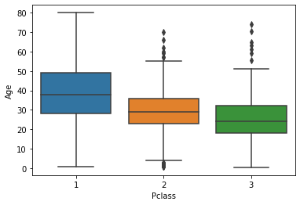

```python
sns.boxplot(x='Pclass',y='Age', data=train_set)
```

```python
#Checking the corealation between the age and survied
#I have made the decision that i will not deed the age column so i will drop the agent column  along the way
train_set.Survived.corr(train_set.Age)
```

```
-0.07686715456890852
```

```python
data = [train_set, test_set]

for dataset in data:
    mean = train_set["Age"].mean()
    std = test_set["Age"].std()
    is_null = dataset["Age"].isnull().sum()
    # compute random numbers between the mean, std and is_null
    rand_age = np.random.randint(mean - std, mean + std, size = is_null)
    # fill NaN values in Age column with random values generated
    age_slice = dataset["Age"].copy()
    age_slice[np.isnan(age_slice)] = rand_age
    dataset["Age"] = age_slice
    dataset["Age"] = train_set["Age"].astype(int)
train_set["Age"].isnull().sum()
```

```
0
```

```python
test_set.head()
```

|  | PassengerId | Pclass | Name | Sex | Age | SibSp | Parch | Fare | Embarked |
| --- | --- | --- | --- | --- | --- | --- | --- | --- | --- |
| 0 | 892 | 3 | Kelly, Mr. James | male | 22 | 0 | 0 | 7.8292 | Q |
| 1 | 893 | 3 | Wilkes, Mrs. James (Ellen Needs) | female | 38 | 1 | 0 | 7.0000 | S |
| 2 | 894 | 2 | Myles, Mr. Thomas Francis | male | 26 | 0 | 0 | 9.6875 | Q |
| 3 | 895 | 3 | Wirz, Mr. Albert | male | 35 | 0 | 0 | 8.6625 | S |
| 4 | 896 | 3 | Hirvonen, Mrs. Alexander (Helga E Lindqvist) | female | 35 | 1 | 1 | 12.2875 | S |

## Convert Sex into numerical values where :

0 = male

1 = female

```python
train_set['Sex'].value_counts(dropna = False)
```

```
male      572
female    309
Name: Sex, dtype: int64
```

```python
#Change male and Female to 0 ,1
train_set["Sex"].replace({"male": 0, "female": 1}, inplace=True)
```

```python
test_set["Sex"].replace({"male": 0, "female": 1}, inplace=True)
```

```python
train_set.head()
```

|  | PassengerId | Survived | Pclass | Name | Sex | Age | SibSp | Parch | Fare | Embarked |
| --- | --- | --- | --- | --- | --- | --- | --- | --- | --- | --- |
| 0 | 1 | 0 | 3 | Braund, Mr. Owen Harris | 0 | 22 | 1 | 0 | 7.2500 | S |
| 1 | 2 | 1 | 1 | Cumings, Mrs. John Bradley (Florence Briggs Th... | 1 | 38 | 1 | 0 | 71.2833 | C |
| 2 | 3 | 1 | 3 | Heikkinen, Miss. Laina | 1 | 26 | 0 | 0 | 7.9250 | S |
| 3 | 4 | 1 | 1 | Futrelle, Mrs. Jacques Heath (Lily May Peel) | 1 | 35 | 1 | 0 | 53.1000 | S |
| 4 | 5 | 0 | 3 | Allen, Mr. William Henry | 0 | 35 | 0 | 0 | 8.0500 | S |

```python
test_set.head()
```

|  | PassengerId | Pclass | Name | Sex | Age | SibSp | Parch | Fare | Embarked |
| --- | --- | --- | --- | --- | --- | --- | --- | --- | --- |
| 0 | 892 | 3 | Kelly, Mr. James | 0 | 22 | 0 | 0 | 7.8292 | Q |
| 1 | 893 | 3 | Wilkes, Mrs. James (Ellen Needs) | 1 | 38 | 1 | 0 | 7.0000 | S |
| 2 | 894 | 2 | Myles, Mr. Thomas Francis | 0 | 26 | 0 | 0 | 9.6875 | Q |
| 3 | 895 | 3 | Wirz, Mr. Albert | 0 | 35 | 0 | 0 | 8.6625 | S |
| 4 | 896 | 3 | Hirvonen, Mrs. Alexander (Helga E Lindqvist) | 1 | 35 | 1 | 1 | 12.2875 | S |

## 5 b) Data transformation

```python
# Combine training set and test set
combine = pd.concat([train_set, test_set], axis = 0).reset_index(drop = True)
combine.head()
```

|  | PassengerId | Survived | Pclass | Name | Sex | Age | SibSp | Parch | Fare | Embarked |
| --- | --- | --- | --- | --- | --- | --- | --- | --- | --- | --- |
| 0 | 1 | 0.0 | 3 | Braund, Mr. Owen Harris | 0 | 22 | 1 | 0 | 7.2500 | S |
| 1 | 2 | 1.0 | 1 | Cumings, Mrs. John Bradley (Florence Briggs Th... | 1 | 38 | 1 | 0 | 71.2833 | C |
| 2 | 3 | 1.0 | 3 | Heikkinen, Miss. Laina | 1 | 26 | 0 | 0 | 7.9250 | S |
| 3 | 4 | 1.0 | 1 | Futrelle, Mrs. Jacques Heath (Lily May Peel) | 1 | 35 | 1 | 0 | 53.1000 | S |
| 4 | 5 | 0.0 | 3 | Allen, Mr. William Henry | 0 | 35 | 0 | 0 | 8.0500 | S |

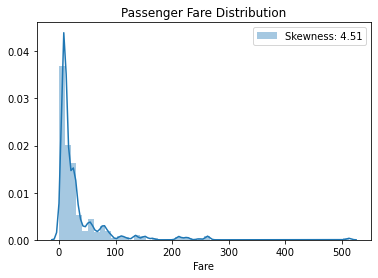

```python
# Passenger fare distribution

sns.distplot(combine['Fare'], label = 'Skewness: %.2f'%(combine['Fare'].skew()))
plt.legend(loc = 'best')
plt.title('Passenger Fare Distribution')
```

```python
# Apply log transformation to Fare column to reduce skewness
combine['Fare'] = combine['Fare'].map(lambda x: np.log(x) if x > 0 else 0)
```

```python
# Apply log transformation to Fare column to reduce skewness
combine['Fare'] = combine['Fare'].map(lambda x: np.log(x) if x > 0 else 0)
```

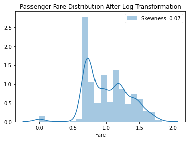

```python
# Passenger fare distribution after log transformation

sns.distplot(combine['Fare'], label = 'Skewness: %.2f'%(combine['Fare'].skew()))
plt.legend(loc = 'best')
plt.title('Passenger Fare Distribution After Log Transformation')
```

```python
train_set
```

|  | PassengerId | Survived | Pclass | Name | Sex | Age | SibSp | Parch | Fare | Embarked |
| --- | --- | --- | --- | --- | --- | --- | --- | --- | --- | --- |
| 0 | 1 | 0 | 3 | Braund, Mr. Owen Harris | 0 | 22 | 1 | 0 | 7.2500 | S |
| 1 | 2 | 1 | 1 | Cumings, Mrs. John Bradley (Florence Briggs Th... | 1 | 38 | 1 | 0 | 71.2833 | C |
| 2 | 3 | 1 | 3 | Heikkinen, Miss. Laina | 1 | 26 | 0 | 0 | 7.9250 | S |
| 3 | 4 | 1 | 1 | Futrelle, Mrs. Jacques Heath (Lily May Peel) | 1 | 35 | 1 | 0 | 53.1000 | S |
| 4 | 5 | 0 | 3 | Allen, Mr. William Henry | 0 | 35 | 0 | 0 | 8.0500 | S |
| ... | ... | ... | ... | ... | ... | ... | ... | ... | ... | ... |
| 876 | 887 | 0 | 2 | Montvila, Rev. Juozas | 0 | 27 | 0 | 0 | 13.0000 | S |
| 877 | 888 | 1 | 1 | Graham, Miss. Margaret Edith | 1 | 19 | 0 | 0 | 30.0000 | S |
| 878 | 889 | 0 | 3 | Johnston, Miss. Catherine Helen "Carrie" | 1 | 24 | 1 | 2 | 23.4500 | S |
| 879 | 890 | 1 | 1 | Behr, Mr. Karl Howell | 0 | 26 | 0 | 0 | 30.0000 | C |
| 880 | 891 | 0 | 3 | Dooley, Mr. Patrick | 0 | 32 | 0 | 0 | 7.7500 | Q |

881 rows × 10 columns

## 5 c) Feature engineering

Feature engineering is arguably the most important art in machine learning. It is the process of creating new features from existing features to better represent the underlying problem to the predictive models resulting in improved model accuracy on unseen data.

In this section, I will construct 3 new features:

i)Title

ii)IsAlone

iii)Age*Class

## 5c) i) Title

```python
data = [train_set, test_set]
titles = {"Mr": 1, "Miss": 2, "Mrs": 3, "Master": 4, "Rare": 5}

for dataset in data:
    # extract titles
    dataset['Title'] = dataset.Name.str.extract(' ([A-Za-z]+)\.', expand=False)
    # replace titles with a more common title or as Rare
    dataset['Title'] = dataset['Title'].replace(['Lady', 'Countess','Capt', 'Col','Don', 'Dr',\
                                            'Major', 'Rev', 'Sir', 'Jonkheer', 'Dona'], 'Rare')
    dataset['Title'] = dataset['Title'].replace('Mlle', 'Miss')
    dataset['Title'] = dataset['Title'].replace('Ms', 'Miss')
    dataset['Title'] = dataset['Title'].replace('Mme', 'Mrs')
    # convert titles into numbers
    dataset['Title'] = dataset['Title'].map(titles)
    # filling NaN with 0, to get safe
    dataset['Title'] = dataset['Title'].fillna(0)
train_set = train_set.drop(['Name'], axis=1)
test_set = test_set.drop(['Name'], axis=1)
```

```python
train_set
```

|  | PassengerId | Survived | Pclass | Sex | Age | SibSp | Parch | Fare | Embarked | Title |
| --- | --- | --- | --- | --- | --- | --- | --- | --- | --- | --- |
| 0 | 1 | 0 | 3 | 0 | 22 | 1 | 0 | 7.2500 | S | 1 |
| 1 | 2 | 1 | 1 | 1 | 38 | 1 | 0 | 71.2833 | C | 3 |
| 2 | 3 | 1 | 3 | 1 | 26 | 0 | 0 | 7.9250 | S | 2 |
| 3 | 4 | 1 | 1 | 1 | 35 | 1 | 0 | 53.1000 | S | 3 |
| 4 | 5 | 0 | 3 | 0 | 35 | 0 | 0 | 8.0500 | S | 1 |
| ... | ... | ... | ... | ... | ... | ... | ... | ... | ... | ... |
| 876 | 887 | 0 | 2 | 0 | 27 | 0 | 0 | 13.0000 | S | 5 |
| 877 | 888 | 1 | 1 | 1 | 19 | 0 | 0 | 30.0000 | S | 2 |
| 878 | 889 | 0 | 3 | 1 | 24 | 1 | 2 | 23.4500 | S | 2 |
| 879 | 890 | 1 | 1 | 0 | 26 | 0 | 0 | 30.0000 | C | 1 |
| 880 | 891 | 0 | 3 | 0 | 32 | 0 | 0 | 7.7500 | Q | 1 |

881 rows × 10 columns

```python
test_set
```

|  | PassengerId | Pclass | Sex | Age | SibSp | Parch | Fare | Embarked | Title |
| --- | --- | --- | --- | --- | --- | --- | --- | --- | --- |
| 0 | 892 | 3 | 0 | 22 | 0 | 0 | 7.8292 | Q | 1 |
| 1 | 893 | 3 | 1 | 38 | 1 | 0 | 7.0000 | S | 3 |
| 2 | 894 | 2 | 0 | 26 | 0 | 0 | 9.6875 | Q | 1 |
| 3 | 895 | 3 | 0 | 35 | 0 | 0 | 8.6625 | S | 1 |
| 4 | 896 | 3 | 1 | 35 | 1 | 1 | 12.2875 | S | 3 |
| ... | ... | ... | ... | ... | ... | ... | ... | ... | ... |
| 413 | 1305 | 3 | 0 | 20 | 0 | 0 | 8.0500 | S | 1 |
| 414 | 1306 | 1 | 1 | 21 | 0 | 0 | 108.9000 | C | 5 |
| 415 | 1307 | 3 | 0 | 29 | 0 | 0 | 7.2500 | S | 1 |
| 416 | 1308 | 3 | 0 | 28 | 0 | 0 | 8.0500 | S | 1 |
| 417 | 1309 | 3 | 0 | 18 | 1 | 1 | 22.3583 | C | 4 |

418 rows × 9 columns

## 5 c) ii) IsAlone

```python
#Create a new feature called  'IsAlone'
data = [train_set, test_set]
for dataset in data:
    dataset['FamilySize'] = dataset['SibSp'] +  dataset['Parch'] + 1
```

```python
for dataset in data:
    dataset['IsAlone'] = 0
    dataset.loc[dataset['FamilySize'] == 1, 'IsAlone'] = 1

print (train_set[['IsAlone', 'Survived']].groupby(['IsAlone'], as_index=False).mean())
```

```
   IsAlone  Survived
0        0  0.514535
1        1  0.303538
```

## 5 c) iii) Age*Class

To create our new Age*Class feature, we need to first transform Age into an ordinal variable. Ordinal variable is much like a categorical variable but with intrisinc ordering in their values.

We will group Ages into 5 separate age bands and assign a number to each age band.

```python
# Let us create Age bands and determine correlations with Survived.

train_set['AgeBand'] = pd.cut(train_set['Age'], 5)
train_set[['AgeBand', 'Survived']].groupby(['AgeBand'], as_index=False).mean().sort_values(by='AgeBand', ascending=True)
```

|  | AgeBand | Survived |
| --- | --- | --- |
| 0 | (-0.08, 16.0] | 0.537037 |
| 1 | (16.0, 32.0] | 0.359813 |
| 2 | (32.0, 48.0] | 0.366038 |
| 3 | (48.0, 64.0] | 0.434783 |
| 4 | (64.0, 80.0] | 0.090909 |

```python
# Let us replace Age with ordinals based on these bands.
data = [train_set, test_set]
for dataset in data:
    dataset.loc[ dataset['Age'] <= 16, 'Age'] = 0
    dataset.loc[(dataset['Age'] > 16) & (dataset['Age'] <= 32), 'Age'] = 1
    dataset.loc[(dataset['Age'] > 32) & (dataset['Age'] <= 48), 'Age'] = 2
    dataset.loc[(dataset['Age'] > 48) & (dataset['Age'] <= 64), 'Age'] = 3
    dataset.loc[ dataset['Age'] > 64, 'Age']
train_set.head()
```

|  | PassengerId | Survived | Pclass | Sex | Age | SibSp | Parch | Fare | Embarked | Title | FamilySize | IsAlone | AgeBand |
| --- | --- | --- | --- | --- | --- | --- | --- | --- | --- | --- | --- | --- | --- |
| 0 | 1 | 0 | 3 | 0 | 1 | 1 | 0 | 7.2500 | S | 1 | 2 | 0 | (16.0, 32.0] |
| 1 | 2 | 1 | 1 | 1 | 2 | 1 | 0 | 71.2833 | C | 3 | 2 | 0 | (32.0, 48.0] |
| 2 | 3 | 1 | 3 | 1 | 1 | 0 | 0 | 7.9250 | S | 2 | 1 | 1 | (16.0, 32.0] |
| 3 | 4 | 1 | 1 | 1 | 2 | 1 | 0 | 53.1000 | S | 3 | 2 | 0 | (32.0, 48.0] |
| 4 | 5 | 0 | 3 | 0 | 2 | 0 | 0 | 8.0500 | S | 1 | 1 | 1 | (32.0, 48.0] |

```python
test_set.head()
```

|  | PassengerId | Pclass | Sex | Age | SibSp | Parch | Fare | Embarked | Title | FamilySize | IsAlone |
| --- | --- | --- | --- | --- | --- | --- | --- | --- | --- | --- | --- |
| 0 | 892 | 3 | 0 | 1 | 0 | 0 | 7.8292 | Q | 1 | 1 | 1 |
| 1 | 893 | 3 | 1 | 2 | 1 | 0 | 7.0000 | S | 3 | 2 | 0 |
| 2 | 894 | 2 | 0 | 1 | 0 | 0 | 9.6875 | Q | 1 | 1 | 1 |
| 3 | 895 | 3 | 0 | 2 | 0 | 0 | 8.6625 | S | 1 | 1 | 1 |
| 4 | 896 | 3 | 1 | 2 | 1 | 1 | 12.2875 | S | 3 | 3 | 0 |

```python
# Drop age band feature

train_set = train_set.drop(['AgeBand'], axis=1)
data  = [train_set, test_set]
train_set.head()
```

|  | PassengerId | Survived | Pclass | Sex | Age | SibSp | Parch | Fare | Embarked | Title | FamilySize | IsAlone |
| --- | --- | --- | --- | --- | --- | --- | --- | --- | --- | --- | --- | --- |
| 0 | 1 | 0 | 3 | 0 | 1 | 1 | 0 | 7.2500 | S | 1 | 2 | 0 |
| 1 | 2 | 1 | 1 | 1 | 2 | 1 | 0 | 71.2833 | C | 3 | 2 | 0 |
| 2 | 3 | 1 | 3 | 1 | 1 | 0 | 0 | 7.9250 | S | 2 | 1 | 1 |
| 3 | 4 | 1 | 1 | 1 | 2 | 1 | 0 | 53.1000 | S | 3 | 2 | 0 |
| 4 | 5 | 0 | 3 | 0 | 2 | 0 | 0 | 8.0500 | S | 1 | 1 | 1 |

```python
# We can also create an artificial feature combining Pclass and Age.

data = [train_set, test_set]
for dataset in data:
    dataset['Age*Class'] = dataset.Age * dataset.Pclass

train_set.loc[:, ['Age*Class', 'Age', 'Pclass']].head(10)
```

|  | Age*Class | Age | Pclass |
| --- | --- | --- | --- |
| 0 | 3 | 1 | 3 |
| 1 | 2 | 2 | 1 |
| 2 | 3 | 1 | 3 |
| 3 | 2 | 2 | 1 |
| 4 | 6 | 2 | 3 |
| 5 | 3 | 1 | 3 |
| 6 | 3 | 3 | 1 |
| 7 | 0 | 0 | 3 |
| 8 | 3 | 1 | 3 |
| 9 | 0 | 0 | 2 |

## 5.d) Feature encoding

Machine learning models require all input and output variables to be numeric. Therefore, we need to encode all of our categorical data before we can fit the models to our data.

Previously, we have encoded the sex column such that 0 = male and 1 = female.We have alreay done the same for the Title Column now its turn for the Embarked Column. In addition, similar to the age column, I will also transform Fare into an ordinal variable rather than a continuous variable.

```python
train_set.head()
```

|  | PassengerId | Survived | Pclass | Sex | Age | SibSp | Parch | Fare | Embarked | Title | FamilySize | IsAlone | Age*Class |
| --- | --- | --- | --- | --- | --- | --- | --- | --- | --- | --- | --- | --- | --- |
| 0 | 1 | 0 | 3 | 0 | 1 | 1 | 0 | 7.2500 | S | 1 | 2 | 0 | 3 |
| 1 | 2 | 1 | 1 | 1 | 2 | 1 | 0 | 71.2833 | C | 3 | 2 | 0 | 2 |
| 2 | 3 | 1 | 3 | 1 | 1 | 0 | 0 | 7.9250 | S | 2 | 1 | 1 | 3 |
| 3 | 4 | 1 | 1 | 1 | 2 | 1 | 0 | 53.1000 | S | 3 | 2 | 0 | 2 |
| 4 | 5 | 0 | 3 | 0 | 2 | 0 | 0 | 8.0500 | S | 1 | 1 | 1 | 6 |

```python
test_set
```

|  | PassengerId | Pclass | Sex | Age | SibSp | Parch | Fare | Embarked | Title | FamilySize | IsAlone | Age*Class |
| --- | --- | --- | --- | --- | --- | --- | --- | --- | --- | --- | --- | --- |
| 0 | 892 | 3 | 0 | 1 | 0 | 0 | 7.8292 | Q | 1 | 1 | 1 | 3 |
| 1 | 893 | 3 | 1 | 2 | 1 | 0 | 7.0000 | S | 3 | 2 | 0 | 6 |
| 2 | 894 | 2 | 0 | 1 | 0 | 0 | 9.6875 | Q | 1 | 1 | 1 | 2 |
| 3 | 895 | 3 | 0 | 2 | 0 | 0 | 8.6625 | S | 1 | 1 | 1 | 6 |
| 4 | 896 | 3 | 1 | 2 | 1 | 1 | 12.2875 | S | 3 | 3 | 0 | 6 |
| ... | ... | ... | ... | ... | ... | ... | ... | ... | ... | ... | ... | ... |
| 413 | 1305 | 3 | 0 | 1 | 0 | 0 | 8.0500 | S | 1 | 1 | 1 | 3 |
| 414 | 1306 | 1 | 1 | 1 | 0 | 0 | 108.9000 | C | 5 | 1 | 1 | 1 |
| 415 | 1307 | 3 | 0 | 1 | 0 | 0 | 7.2500 | S | 1 | 1 | 1 | 3 |
| 416 | 1308 | 3 | 0 | 1 | 0 | 0 | 8.0500 | S | 1 | 1 | 1 | 3 |
| 417 | 1309 | 3 | 0 | 1 | 1 | 1 | 22.3583 | C | 4 | 3 | 0 | 3 |

418 rows × 12 columns

## Encode Embarked feature

```python
ports = pd.get_dummies(train_set.Embarked, prefix = 'Embarked')
ports.head()
```

|  | Embarked_C | Embarked_Q | Embarked_S |
| --- | --- | --- | --- |
| 0 | 0 | 0 | 1 |
| 1 | 1 | 0 | 0 |
| 2 | 0 | 0 | 1 |
| 3 | 0 | 0 | 1 |
| 4 | 0 | 0 | 1 |

```python
ports_1= pd.get_dummies(test_set.Embarked, prefix = 'Embarked')
ports_1.head()
```

|  | Embarked_C | Embarked_Q | Embarked_S |
| --- | --- | --- | --- |
| 0 | 0 | 1 | 0 |
| 1 | 0 | 0 | 1 |
| 2 | 0 | 1 | 0 |
| 3 | 0 | 0 | 1 |
| 4 | 0 | 0 | 1 |

```python
train_set = train_set.join(ports)
train_set.drop(['Embarked'], axis = 1 , inplace = True)
```

```python
test_set = test_set.join(ports_1)
test_set.drop(['Embarked'], axis = 1 , inplace = True)
```

```python
train_set
```

|  | PassengerId | Survived | Pclass | Sex | Age | SibSp | Parch | Fare | Title | FamilySize | IsAlone | Age*Class | Embarked_C | Embarked_Q | Embarked_S |
| --- | --- | --- | --- | --- | --- | --- | --- | --- | --- | --- | --- | --- | --- | --- | --- |
| 0 | 1 | 0 | 3 | 0 | 1 | 1 | 0 | 7.2500 | 1 | 2 | 0 | 3 | 0 | 0 | 1 |
| 1 | 2 | 1 | 1 | 1 | 2 | 1 | 0 | 71.2833 | 3 | 2 | 0 | 2 | 1 | 0 | 0 |
| 2 | 3 | 1 | 3 | 1 | 1 | 0 | 0 | 7.9250 | 2 | 1 | 1 | 3 | 0 | 0 | 1 |
| 3 | 4 | 1 | 1 | 1 | 2 | 1 | 0 | 53.1000 | 3 | 2 | 0 | 2 | 0 | 0 | 1 |
| 4 | 5 | 0 | 3 | 0 | 2 | 0 | 0 | 8.0500 | 1 | 1 | 1 | 6 | 0 | 0 | 1 |
| ... | ... | ... | ... | ... | ... | ... | ... | ... | ... | ... | ... | ... | ... | ... | ... |
| 876 | 887 | 0 | 2 | 0 | 1 | 0 | 0 | 13.0000 | 5 | 1 | 1 | 2 | 0 | 0 | 1 |
| 877 | 888 | 1 | 1 | 1 | 1 | 0 | 0 | 30.0000 | 2 | 1 | 1 | 1 | 0 | 0 | 1 |
| 878 | 889 | 0 | 3 | 1 | 1 | 1 | 2 | 23.4500 | 2 | 4 | 0 | 3 | 0 | 0 | 1 |
| 879 | 890 | 1 | 1 | 0 | 1 | 0 | 0 | 30.0000 | 1 | 1 | 1 | 1 | 1 | 0 | 0 |
| 880 | 891 | 0 | 3 | 0 | 1 | 0 | 0 | 7.7500 | 1 | 1 | 1 | 3 | 0 | 1 | 0 |

881 rows × 15 columns

```python
test_set
```

|  | PassengerId | Pclass | Sex | Age | SibSp | Parch | Fare | Title | FamilySize | IsAlone | Age*Class | Embarked_C | Embarked_Q | Embarked_S |
| --- | --- | --- | --- | --- | --- | --- | --- | --- | --- | --- | --- | --- | --- | --- |
| 0 | 892 | 3 | 0 | 1 | 0 | 0 | 7.8292 | 1 | 1 | 1 | 3 | 0 | 1 | 0 |
| 1 | 893 | 3 | 1 | 2 | 1 | 0 | 7.0000 | 3 | 2 | 0 | 6 | 0 | 0 | 1 |
| 2 | 894 | 2 | 0 | 1 | 0 | 0 | 9.6875 | 1 | 1 | 1 | 2 | 0 | 1 | 0 |
| 3 | 895 | 3 | 0 | 2 | 0 | 0 | 8.6625 | 1 | 1 | 1 | 6 | 0 | 0 | 1 |
| 4 | 896 | 3 | 1 | 2 | 1 | 1 | 12.2875 | 3 | 3 | 0 | 6 | 0 | 0 | 1 |
| ... | ... | ... | ... | ... | ... | ... | ... | ... | ... | ... | ... | ... | ... | ... |
| 413 | 1305 | 3 | 0 | 1 | 0 | 0 | 8.0500 | 1 | 1 | 1 | 3 | 0 | 0 | 1 |
| 414 | 1306 | 1 | 1 | 1 | 0 | 0 | 108.9000 | 5 | 1 | 1 | 1 | 1 | 0 | 0 |
| 415 | 1307 | 3 | 0 | 1 | 0 | 0 | 7.2500 | 1 | 1 | 1 | 3 | 0 | 0 | 1 |
| 416 | 1308 | 3 | 0 | 1 | 0 | 0 | 8.0500 | 1 | 1 | 1 | 3 | 0 | 0 | 1 |
| 417 | 1309 | 3 | 0 | 1 | 1 | 1 | 22.3583 | 4 | 3 | 0 | 3 | 1 | 0 | 0 |

418 rows × 14 columns

## Encoding the Fare Column

```python
train_set.Fare.unique()
```

```
array([  7.25  ,  71.2833,   7.925 ,  53.1   ,   8.05  ,   8.4583,
        51.8625,  21.075 ,  11.1333,  30.0708,  16.7   ,  26.55  ,
        31.275 ,   7.8542,  16.    ,  29.125 ,  13.    ,  18.    ,
         7.225 ,  26.    ,   8.0292,  35.5   ,  31.3875,   7.8792,
         7.8958,  27.7208, 146.5208,   7.75  ,  10.5   ,  82.1708,
        52.    ,   7.2292,  11.2417,   9.475 ,  21.    ,  41.5792,
        15.5   ,  21.6792,  17.8   ,  39.6875,   7.8   ,  76.7292,
        61.9792,  27.75  ,  46.9   ,  80.    ,  83.475 ,  27.9   ,
        15.2458,   8.1583,   8.6625,  73.5   ,  14.4542,  56.4958,
         7.65  ,  29.    ,  12.475 ,   9.    ,   9.5   ,   7.7875,
        47.1   ,  15.85  ,  34.375 ,  61.175 ,  20.575 ,  34.6542,
        63.3583,  23.    ,  77.2875,   8.6542,   7.775 ,  24.15  ,
         9.825 ,  14.4583, 247.5208,   7.1417,  22.3583,   6.975 ,
         7.05  ,  14.5   ,  15.0458,  26.2833,   9.2167,  79.2   ,
         6.75  ,  11.5   ,  36.75  ,   7.7958,  12.525 ,  66.6   ,
         7.3125,  61.3792,   7.7333,  16.1   ,  15.75  ,  20.525 ,
        55.    ,  25.925 ,  33.5   ,  30.6958,  25.4667,  28.7125,
         0.    ,  15.05  ,  39.    ,  22.025 ,  50.    ,   8.4042,
         6.4958,  10.4625,  18.7875,  31.    , 113.275 ,  27.    ,
        76.2917,  90.    ,   9.35  ,  13.5   ,   7.55  ,  26.25  ,
        12.275 ,   7.125 ,  52.5542,  20.2125,  86.5   , 512.3292,
        79.65  , 153.4625, 135.6333,  19.5   ,  29.7   ,  77.9583,
        20.25  ,  78.85  ,  91.0792,  12.875 ,   8.85  , 151.55  ,
        30.5   ,  23.25  ,  12.35  , 110.8833, 108.9   ,  24.    ,
        56.9292,  83.1583, 262.375 ,  14.    , 164.8667, 134.5   ,
         6.2375,  57.9792,  28.5   , 133.65  ,  15.9   ,   9.225 ,
        35.    ,  75.25  ,  69.3   ,  55.4417, 211.5   ,   4.0125,
       227.525 ,  15.7417,   7.7292,  12.    , 120.    ,  12.65  ,
        18.75  ,   6.8583,  32.5   ,   7.875 ,  14.4   ,  55.9   ,
       263.    ,   8.1125,  81.8583,  19.2583,  19.9667,  89.1042,
        38.5   ,   7.725 ,  13.7917,   9.8375,   7.0458,   7.5208,
        12.2875,   9.5875,  49.5042,  78.2667,  15.1   ,   7.6292,
        22.525 ,  26.2875,  59.4   ,   7.4958,  34.0208,  93.5   ,
       221.7792, 106.425 ,  49.5   ,  71.    ,  13.8625,   7.8292,
        39.6   ,  17.4   ,  51.4792,  26.3875,  30.    ,  40.125 ,
         8.7125,  15.    ,  33.    ,  42.4   ,  15.55  ,  65.    ,
        32.3208,   7.0542,   8.4333,  25.5875,   9.8417,   8.1375,
        10.1708, 211.3375,  57.    ,  13.4167,   7.7417,   9.4833,
         7.7375,   8.3625,  23.45  ,  25.9292,   8.6833,   8.5167,
         7.8875,  37.0042,   6.45  ,   6.95  ,   8.3   ,   6.4375,
        39.4   ,  14.1083,  13.8583,  50.4958,   5.    ,   9.8458,
        10.5167])
```

```python
# calculate the range of value in Fare column.
print("Range of Fare column values = ", train_set.Fare.max() - train_set.Fare.min())
# min value is 0.0 and max value = 512.3292
# i will divied this range to 10 sections.
test_set.Fare.replace(np.nan, test_set.Fare.mean(), inplace=True)
print("Range of Fare column values = ", test_set.Fare.max() - test_set.Fare.min())
```

```
Range of Fare column values =  512.3292
Range of Fare column values =  512.3292
```

```python
train_set.Fare = train_set.Fare.astype("int64")
test_set.Fare = test_set.Fare.astype("int64")
```

```python
# Convert Fare into integer
combine['Fare'] = combine['Fare'].astype('int')
```

```python
train_set.head()
```

|  | PassengerId | Survived | Pclass | Sex | Age | SibSp | Parch | Fare | Title | FamilySize | IsAlone | Age*Class | Embarked_C | Embarked_Q | Embarked_S |
| --- | --- | --- | --- | --- | --- | --- | --- | --- | --- | --- | --- | --- | --- | --- | --- |
| 0 | 1 | 0 | 3 | 0 | 1 | 1 | 0 | 7 | 1 | 2 | 0 | 3 | 0 | 0 | 1 |
| 1 | 2 | 1 | 1 | 1 | 2 | 1 | 0 | 71 | 3 | 2 | 0 | 2 | 1 | 0 | 0 |
| 2 | 3 | 1 | 3 | 1 | 1 | 0 | 0 | 7 | 2 | 1 | 1 | 3 | 0 | 0 | 1 |
| 3 | 4 | 1 | 1 | 1 | 2 | 1 | 0 | 53 | 3 | 2 | 0 | 2 | 0 | 0 | 1 |
| 4 | 5 | 0 | 3 | 0 | 2 | 0 | 0 | 8 | 1 | 1 | 1 | 6 | 0 | 0 | 1 |

```python
test_set.head()
```

|  | PassengerId | Pclass | Sex | Age | SibSp | Parch | Fare | Title | FamilySize | IsAlone | Age*Class | Embarked_C | Embarked_Q | Embarked_S |
| --- | --- | --- | --- | --- | --- | --- | --- | --- | --- | --- | --- | --- | --- | --- |
| 0 | 892 | 3 | 0 | 1 | 0 | 0 | 7 | 1 | 1 | 1 | 3 | 0 | 1 | 0 |
| 1 | 893 | 3 | 1 | 2 | 1 | 0 | 7 | 3 | 2 | 0 | 6 | 0 | 0 | 1 |
| 2 | 894 | 2 | 0 | 1 | 0 | 0 | 9 | 1 | 1 | 1 | 2 | 0 | 1 | 0 |
| 3 | 895 | 3 | 0 | 2 | 0 | 0 | 8 | 1 | 1 | 1 | 6 | 0 | 0 | 1 |
| 4 | 896 | 3 | 1 | 2 | 1 | 1 | 12 | 3 | 3 | 0 | 6 | 0 | 0 | 1 |

```python
bins_i = [-1, 50, 100, 150, 200, 250, 300, 350, 400, 450, 500, 550]
labels_i = [1,2,3,4,5,6,7,8,9,10,11]

train_set['stage'] = 0
train_set['stage'] = pd.cut(train_set.Fare, bins=bins_i, labels=labels_i)

test_set['stage'] = 0
test_set['stage'] = pd.cut(test_set.Fare, bins=bins_i, labels=labels_i)

train_set.stage.unique()
```

```
[1, 2, 3, 5, 11, 4, 6]
Categories (7, int64): [1 < 2 < 3 < 4 < 5 < 6 < 11]
```

```python
train_set.Fare = train_set.stage.astype("int64")
test_set.Fare = test_set.stage.astype("int64")
train_set.drop("stage", axis=1, inplace=True)
test_set.drop("stage", axis=1, inplace=True)
```

```python
train_set.head()
```

|  | PassengerId | Survived | Pclass | Sex | Age | SibSp | Parch | Fare | Title | FamilySize | IsAlone | Age*Class | Embarked_C | Embarked_Q | Embarked_S |
| --- | --- | --- | --- | --- | --- | --- | --- | --- | --- | --- | --- | --- | --- | --- | --- |
| 0 | 1 | 0 | 3 | 0 | 1 | 1 | 0 | 1 | 1 | 2 | 0 | 3 | 0 | 0 | 1 |
| 1 | 2 | 1 | 1 | 1 | 2 | 1 | 0 | 2 | 3 | 2 | 0 | 2 | 1 | 0 | 0 |
| 2 | 3 | 1 | 3 | 1 | 1 | 0 | 0 | 1 | 2 | 1 | 1 | 3 | 0 | 0 | 1 |
| 3 | 4 | 1 | 1 | 1 | 2 | 1 | 0 | 2 | 3 | 2 | 0 | 2 | 0 | 0 | 1 |
| 4 | 5 | 0 | 3 | 0 | 2 | 0 | 0 | 1 | 1 | 1 | 1 | 6 | 0 | 0 | 1 |

```python
test_set.head()
```

|  | PassengerId | Pclass | Sex | Age | SibSp | Parch | Fare | Title | FamilySize | IsAlone | Age*Class | Embarked_C | Embarked_Q | Embarked_S |
| --- | --- | --- | --- | --- | --- | --- | --- | --- | --- | --- | --- | --- | --- | --- |
| 0 | 892 | 3 | 0 | 1 | 0 | 0 | 1 | 1 | 1 | 1 | 3 | 0 | 1 | 0 |
| 1 | 893 | 3 | 1 | 2 | 1 | 0 | 1 | 3 | 2 | 0 | 6 | 0 | 0 | 1 |
| 2 | 894 | 2 | 0 | 1 | 0 | 0 | 1 | 1 | 1 | 1 | 2 | 0 | 1 | 0 |
| 3 | 895 | 3 | 0 | 2 | 0 | 0 | 1 | 1 | 1 | 1 | 6 | 0 | 0 | 1 |
| 4 | 896 | 3 | 1 | 2 | 1 | 1 | 1 | 3 | 3 | 0 | 6 | 0 | 0 | 1 |

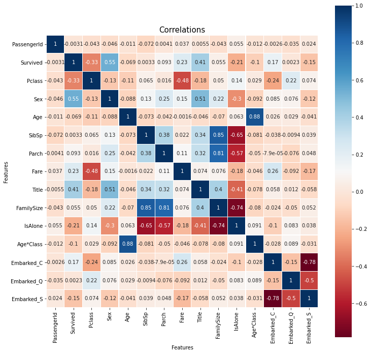

```python
colormap=plt.cm.RdBu
figure = plt.figure(figsize=(12,12))
sns.heatmap(train_set.corr(),linewidths=0.1,vmax=1.0, square=True, cmap=colormap, linecolor='white', annot=True)
plt.title("Correlations",size=15)
plt.xlabel("Features")
plt.ylabel("Features")
plt.show()
```

Now Finally Our Data is ready for modelling

```python
train_set
```

|  | PassengerId | Survived | Pclass | Sex | Age | SibSp | Parch | Fare | Title | FamilySize | IsAlone | Age*Class | Embarked_C | Embarked_Q | Embarked_S |
| --- | --- | --- | --- | --- | --- | --- | --- | --- | --- | --- | --- | --- | --- | --- | --- |
| 0 | 1 | 0 | 3 | 0 | 1 | 1 | 0 | 1 | 1 | 2 | 0 | 3 | 0 | 0 | 1 |
| 1 | 2 | 1 | 1 | 1 | 2 | 1 | 0 | 2 | 3 | 2 | 0 | 2 | 1 | 0 | 0 |
| 2 | 3 | 1 | 3 | 1 | 1 | 0 | 0 | 1 | 2 | 1 | 1 | 3 | 0 | 0 | 1 |
| 3 | 4 | 1 | 1 | 1 | 2 | 1 | 0 | 2 | 3 | 2 | 0 | 2 | 0 | 0 | 1 |
| 4 | 5 | 0 | 3 | 0 | 2 | 0 | 0 | 1 | 1 | 1 | 1 | 6 | 0 | 0 | 1 |
| ... | ... | ... | ... | ... | ... | ... | ... | ... | ... | ... | ... | ... | ... | ... | ... |
| 876 | 887 | 0 | 2 | 0 | 1 | 0 | 0 | 1 | 5 | 1 | 1 | 2 | 0 | 0 | 1 |
| 877 | 888 | 1 | 1 | 1 | 1 | 0 | 0 | 1 | 2 | 1 | 1 | 1 | 0 | 0 | 1 |
| 878 | 889 | 0 | 3 | 1 | 1 | 1 | 2 | 1 | 2 | 4 | 0 | 3 | 0 | 0 | 1 |
| 879 | 890 | 1 | 1 | 0 | 1 | 0 | 0 | 1 | 1 | 1 | 1 | 1 | 1 | 0 | 0 |
| 880 | 891 | 0 | 3 | 0 | 1 | 0 | 0 | 1 | 1 | 1 | 1 | 3 | 0 | 1 | 0 |

881 rows × 15 columns

```python
test_set
```

|  | PassengerId | Pclass | Sex | Age | SibSp | Parch | Fare | Title | FamilySize | IsAlone | Age*Class | Embarked_C | Embarked_Q | Embarked_S |
| --- | --- | --- | --- | --- | --- | --- | --- | --- | --- | --- | --- | --- | --- | --- |
| 0 | 892 | 3 | 0 | 1 | 0 | 0 | 1 | 1 | 1 | 1 | 3 | 0 | 1 | 0 |
| 1 | 893 | 3 | 1 | 2 | 1 | 0 | 1 | 3 | 2 | 0 | 6 | 0 | 0 | 1 |
| 2 | 894 | 2 | 0 | 1 | 0 | 0 | 1 | 1 | 1 | 1 | 2 | 0 | 1 | 0 |
| 3 | 895 | 3 | 0 | 2 | 0 | 0 | 1 | 1 | 1 | 1 | 6 | 0 | 0 | 1 |
| 4 | 896 | 3 | 1 | 2 | 1 | 1 | 1 | 3 | 3 | 0 | 6 | 0 | 0 | 1 |
| ... | ... | ... | ... | ... | ... | ... | ... | ... | ... | ... | ... | ... | ... | ... |
| 413 | 1305 | 3 | 0 | 1 | 0 | 0 | 1 | 1 | 1 | 1 | 3 | 0 | 0 | 1 |
| 414 | 1306 | 1 | 1 | 1 | 0 | 0 | 3 | 5 | 1 | 1 | 1 | 1 | 0 | 0 |
| 415 | 1307 | 3 | 0 | 1 | 0 | 0 | 1 | 1 | 1 | 1 | 3 | 0 | 0 | 1 |
| 416 | 1308 | 3 | 0 | 1 | 0 | 0 | 1 | 1 | 1 | 1 | 3 | 0 | 0 | 1 |
| 417 | 1309 | 3 | 0 | 1 | 1 | 1 | 1 | 4 | 3 | 0 | 3 | 1 | 0 | 0 |

418 rows × 14 columns

```python
train_set.drop(["PassengerId",  "SibSp", "Parch", ], axis=1, inplace=True)
test_set.drop(["SibSp", "Parch"], axis=1, inplace=True)
```

```python
train_set
```

|  | Survived | Pclass | Sex | Age | Fare | Title | FamilySize | IsAlone | Age*Class | Embarked_C | Embarked_Q | Embarked_S |
| --- | --- | --- | --- | --- | --- | --- | --- | --- | --- | --- | --- | --- |
| 0 | 0 | 3 | 0 | 1 | 1 | 1 | 2 | 0 | 3 | 0 | 0 | 1 |
| 1 | 1 | 1 | 1 | 2 | 2 | 3 | 2 | 0 | 2 | 1 | 0 | 0 |
| 2 | 1 | 3 | 1 | 1 | 1 | 2 | 1 | 1 | 3 | 0 | 0 | 1 |
| 3 | 1 | 1 | 1 | 2 | 2 | 3 | 2 | 0 | 2 | 0 | 0 | 1 |
| 4 | 0 | 3 | 0 | 2 | 1 | 1 | 1 | 1 | 6 | 0 | 0 | 1 |
| ... | ... | ... | ... | ... | ... | ... | ... | ... | ... | ... | ... | ... |
| 876 | 0 | 2 | 0 | 1 | 1 | 5 | 1 | 1 | 2 | 0 | 0 | 1 |
| 877 | 1 | 1 | 1 | 1 | 1 | 2 | 1 | 1 | 1 | 0 | 0 | 1 |
| 878 | 0 | 3 | 1 | 1 | 1 | 2 | 4 | 0 | 3 | 0 | 0 | 1 |
| 879 | 1 | 1 | 0 | 1 | 1 | 1 | 1 | 1 | 1 | 1 | 0 | 0 |
| 880 | 0 | 3 | 0 | 1 | 1 | 1 | 1 | 1 | 3 | 0 | 1 | 0 |

881 rows × 12 columns

```python
train_set.shape
```

```
(881, 12)
```

```python
test_set
```

|  | PassengerId | Pclass | Sex | Age | Fare | Title | FamilySize | IsAlone | Age*Class | Embarked_C | Embarked_Q | Embarked_S |
| --- | --- | --- | --- | --- | --- | --- | --- | --- | --- | --- | --- | --- |
| 0 | 892 | 3 | 0 | 1 | 1 | 1 | 1 | 1 | 3 | 0 | 1 | 0 |
| 1 | 893 | 3 | 1 | 2 | 1 | 3 | 2 | 0 | 6 | 0 | 0 | 1 |
| 2 | 894 | 2 | 0 | 1 | 1 | 1 | 1 | 1 | 2 | 0 | 1 | 0 |
| 3 | 895 | 3 | 0 | 2 | 1 | 1 | 1 | 1 | 6 | 0 | 0 | 1 |
| 4 | 896 | 3 | 1 | 2 | 1 | 3 | 3 | 0 | 6 | 0 | 0 | 1 |
| ... | ... | ... | ... | ... | ... | ... | ... | ... | ... | ... | ... | ... |
| 413 | 1305 | 3 | 0 | 1 | 1 | 1 | 1 | 1 | 3 | 0 | 0 | 1 |
| 414 | 1306 | 1 | 1 | 1 | 3 | 5 | 1 | 1 | 1 | 1 | 0 | 0 |
| 415 | 1307 | 3 | 0 | 1 | 1 | 1 | 1 | 1 | 3 | 0 | 0 | 1 |
| 416 | 1308 | 3 | 0 | 1 | 1 | 1 | 1 | 1 | 3 | 0 | 0 | 1 |
| 417 | 1309 | 3 | 0 | 1 | 1 | 4 | 3 | 0 | 3 | 1 | 0 | 0 |

418 rows × 12 columns

```python
test_set.shape
```

```
(418, 12)
```

Now Finally Our Data is ready for modelling

## 6 Model, predict and solve

Now we are ready to train a model and predict the required solution. There are 60+ predictive modelling algorithms to choose from. We must understand the type of problem and solution requirement to narrow down to a select few models which we can evaluate. Our problem is a classification and regression problem. We want to identify relationship between output (Survived or not) with other variables or features (Gender, Age, Port...). We are also perfoming a category of machine learning which is called supervised learning as we are training our model with a given dataset. With these two criteria - Supervised Learning plus Classification and Regression, we can narrow down our choice of models to a few. These include:

Logistic Regression

KNN or k-Nearest Neighbors

Support Vector Machines

Naive Bayes classifier

Decision Tree

Random Forrest

Perceptron

Artificial neural network

RVM or Relevance Vector Machine

## 6.a) Split training data

We need to first split our training data into independent variables or predictor variables, represented by X as well as dependent variable or response variable, represented by Y.

Y_train is the survived column in our training set and X_train is the other columns in the training set excluding the Survived column. Our models will learn to classify survival, Y_train based on all X_train and make predictions on X_test.

```python
X_train = train_set.drop("Survived", axis=1)
Y_train = train_set["Survived"]
X_test  = test_set.drop("PassengerId", axis=1).copy()
X_train.shape, Y_train.shape, X_test.shape
```

```
((881, 11), (881,), (418, 11))
```

## 6.b) Fit model to data and make predictions

This requires 3 simple steps: instantiate the model, fit the model to the training set and predict the data in test set.

Logistic Regression

is a useful model to run early in the workflow. Logistic regression measures the relationship between the categorical dependent variable (feature) and one or more independent variables (features) by estimating probabilities using a logistic function, which is the cumulative logistic distribution. Reference Wikipedia.

Note the confidence score generated by the model based on our training dataset.

### 6.b.1 Logistic regression

```python
logreg = LogisticRegression()
logreg.fit(X_train, Y_train)
Y_pred = logreg.predict(X_test)
acc_log = round(logreg.score(X_train, Y_train) * 100, 2)
acc_log
```

```
81.38
```

We can use Logistic Regression to validate our assumptions and decisions for feature creating and completing goals. This can be done by calculating the coefficient of the features in the decision function.

Positive coefficients increase the log-odds of the response (and thus increase the probability), and negative coefficients decrease the log-odds of the response (and thus decrease the probability).

Sex is highest positivie coefficient, implying as the Sex value increases (male: 0 to female: 1), the probability of Survived=1 increases the most.

So is Title as second highest positive correlation.

```python
coeff_df = pd.DataFrame(train_set.columns.delete(0))
coeff_df.columns = ['Feature']
coeff_df["Correlation"] = pd.Series(logreg.coef_[0])

coeff_df.sort_values(by='Correlation', ascending=False)
```

|  | Feature | Correlation |
| --- | --- | --- |
| 1 | Sex | 2.194242 |
| 4 | Title | 0.471961 |
| 2 | Age | 0.327633 |
| 3 | Fare | 0.173096 |
| 8 | Embarked_C | 0.129977 |
| 9 | Embarked_Q | 0.073931 |
| 10 | Embarked_S | -0.204803 |
| 7 | Age*Class | -0.349849 |
| 0 | Pclass | -0.384340 |
| 5 | FamilySize | -0.408620 |
| 6 | IsAlone | -0.527918 |

### 6.b.2 Support vector machines

```python
svc = SVC()
svc.fit(X_train, Y_train)
Y_pred = svc.predict(X_test)
acc_svc = round(svc.score(X_train, Y_train) * 100, 2)
acc_svc
```

```
82.29
```

### 6.b.3 K-nearest neighbours (KNN)

```python
knn = KNeighborsClassifier(n_neighbors = 5)
knn.fit(X_train, Y_train)
Y_pred = knn.predict(X_test)
acc_knn = round(knn.score(X_train, Y_train) * 100, 2)
acc_knn
```

```
84.34
```

### 6.b.4 Gaussian naive bayes

```python
gaussian = GaussianNB()
gaussian.fit(X_train, Y_train)
Y_pred = gaussian.predict(X_test)
acc_gaussian = round(gaussian.score(X_train, Y_train) * 100, 2)
acc_gaussian
```

```
77.07
```

### 6.b.5 Perceptron

```python
perceptron = Perceptron()
perceptron.fit(X_train, Y_train)
Y_pred = perceptron.predict(X_test)
acc_perceptron = round(perceptron.score(X_train, Y_train) * 100, 2)
acc_perceptron
```

```
68.79
```

### 6.b.6 Linear SVC

```python
linear_svc = LinearSVC()
linear_svc.fit(X_train, Y_train)
Y_pred = linear_svc.predict(X_test)
acc_linear_svc = round(linear_svc.score(X_train, Y_train) * 100, 2)
acc_linear_svc
```

```
81.16
```

```python
sgd = SGDClassifier()
sgd.fit(X_train, Y_train)
Y_pred = sgd.predict(X_test)
acc_sgd = round(sgd.score(X_train, Y_train) * 100, 2)
acc_sgd
```

```
75.71
```

### 6.b.8 Decision tree

```python
decision_tree = DecisionTreeClassifier()
decision_tree.fit(X_train, Y_train)
Y_pred = decision_tree.predict(X_test)
acc_decision_tree = round(decision_tree.score(X_train, Y_train) * 100, 2)
acc_decision_tree
```

```
87.74
```

### 6.b.9 Random forest

```python
random_forest = RandomForestClassifier(n_estimators = 100)
random_forest.fit(X_train, Y_train)
Y_pred = random_forest.predict(X_test)
acc_random_forest = round(random_forest.score(X_train, Y_train) * 100, 2)
acc_random_forest
```

```
87.74
```

## 6.c Model evaluation and hyperparameter tuning

### 6.3.a Training accuracy

Training accuracy shows how well our model has learned from the training set.

```python
models = pd.DataFrame({
    'Model': ['Support Vector Machines', 'KNN', 'Logistic Regression',
              'Random Forest', 'Naive Bayes', 'Perceptron',
              'Stochastic Gradient Decent', 'Linear SVC',
              'Decision Tree'],
    'Score': [acc_svc, acc_knn, acc_log,
              acc_random_forest, acc_gaussian, acc_perceptron,
              acc_sgd, acc_linear_svc, acc_decision_tree]})
models.sort_values(by='Score', ascending=False)
```

|  | Model | Score |
| --- | --- | --- |
| 3 | Random Forest | 87.74 |
| 8 | Decision Tree | 87.74 |
| 1 | KNN | 84.34 |
| 0 | Support Vector Machines | 82.29 |
| 2 | Logistic Regression | 81.38 |
| 7 | Linear SVC | 81.16 |
| 4 | Naive Bayes | 77.07 |
| 6 | Stochastic Gradient Decent | 75.71 |
| 5 | Perceptron | 68.79 |

### Training accuracy

```python
svc = SVC(C = 100, gamma = 0.01, kernel = 'rbf')
svc.fit(X_train, Y_train)
Y_pred = svc.predict(X_test)
acc_svc = round(svc.score(X_train, Y_train) * 100, 2)
acc_svc
```

```
83.88
```

### Mean cross validation score

```python
cross_val_score(svc, X_train, Y_train, scoring = 'accuracy', cv = 10).mean()
```

```
0.8342696629213483
```

### Survival predictions by support vector classifier

```python
Y_pred
```

```
array([0, 1, 0, 0, 0, 0, 1, 0, 1, 0, 0, 0, 1, 0, 1, 1, 0, 0, 1, 1, 0, 0,
       1, 0, 1, 0, 1, 0, 0, 0, 0, 0, 0, 1, 0, 0, 1, 1, 0, 0, 0, 0, 0, 1,
       1, 0, 0, 0, 1, 1, 0, 0, 1, 0, 0, 0, 0, 0, 0, 1, 0, 0, 0, 1, 1, 1,
       1, 0, 0, 1, 1, 0, 1, 0, 1, 0, 0, 1, 0, 1, 1, 0, 0, 0, 0, 0, 1, 1,
       1, 1, 1, 0, 1, 0, 0, 0, 1, 0, 1, 0, 1, 0, 0, 0, 1, 0, 0, 0, 0, 0,
       0, 1, 1, 1, 0, 0, 0, 1, 0, 1, 1, 0, 1, 0, 0, 1, 0, 0, 0, 0, 0, 0,
       0, 0, 0, 0, 0, 0, 1, 0, 0, 1, 0, 0, 0, 0, 0, 0, 0, 0, 1, 0, 0, 0,
       0, 0, 1, 1, 0, 1, 1, 1, 1, 0, 0, 0, 0, 0, 1, 1, 0, 0, 0, 0, 0, 1,
       1, 0, 1, 1, 0, 0, 1, 0, 1, 0, 1, 0, 0, 0, 0, 0, 0, 0, 1, 0, 1, 1,
       0, 1, 1, 0, 1, 1, 0, 0, 1, 0, 1, 0, 0, 0, 0, 1, 0, 0, 1, 0, 1, 0,
       1, 0, 1, 0, 1, 1, 0, 1, 0, 0, 0, 1, 0, 0, 0, 0, 0, 0, 1, 1, 1, 1,
       0, 0, 0, 0, 1, 0, 1, 1, 1, 0, 0, 0, 0, 0, 0, 0, 1, 0, 0, 0, 1, 0,
       0, 0, 0, 0, 1, 0, 0, 0, 1, 1, 0, 0, 0, 0, 0, 0, 1, 0, 1, 0, 1, 0,
       0, 0, 0, 0, 0, 1, 0, 1, 0, 0, 1, 0, 0, 0, 0, 0, 0, 0, 1, 1, 0, 0,
       0, 1, 0, 0, 0, 1, 1, 1, 0, 0, 0, 0, 0, 0, 0, 0, 1, 0, 1, 0, 0, 0,
       1, 0, 0, 1, 0, 0, 0, 0, 0, 0, 0, 0, 0, 1, 0, 1, 0, 1, 0, 1, 1, 0,
       0, 0, 0, 0, 1, 0, 0, 1, 0, 1, 1, 0, 1, 0, 0, 1, 1, 0, 0, 1, 0, 0,
       1, 1, 0, 0, 0, 0, 0, 0, 1, 1, 0, 1, 0, 0, 0, 0, 0, 1, 0, 0, 0, 1,
       0, 1, 0, 0, 1, 0, 1, 0, 0, 0, 0, 0, 1, 0, 1, 1, 1, 0, 1, 0, 0, 1],
      dtype=int64)
```

```python
len(Y_pred)
```

```
418
```

## 7. Preparing data for submission

```python
ss.head()
```

|  | PassengerId | Survived |
| --- | --- | --- |
| 0 | 892 | 0 |
| 1 | 893 | 1 |
| 2 | 894 | 0 |
| 3 | 895 | 0 |
| 4 | 896 | 1 |

```python
ss.shape
```

```
(418, 2)
```

We want our submission dataframe to have 418 rows and 2 columns, PassengerId and Survived.

### Create submission dataframe

```python
submit = pd.DataFrame({'PassengerId': test_set['PassengerId'], 'Survived': Y_pred})
submit.head()
```

|  | PassengerId | Survived |
| --- | --- | --- |
| 0 | 892 | 0 |
| 1 | 893 | 1 |
| 2 | 894 | 0 |
| 3 | 895 | 0 |
| 4 | 896 | 0 |

```python
submit.shape
```

```
(418, 2)
```

Finally our dataframe is ready for submission!

```python
# Create and save csv file
submit.to_csv("C:/Users/DMONGARE/Desktop/J projects/svm_titanic.csv", index = False)
```

`Kindly feel free to correct me where you feel I need to improve. Your feedback will be highly appreciated.